# Project 2

Justin Feathers & Luke Perkins

2022-10-08

# Overview

The purpose of this vignette is to explain how to use a function created for interacting with a specific API, as well as demonstrate various types of analyses that can be conducted on the data obtained from its use. The [Beer API](https://www.openbrewerydb.org/) is a free API that contains publicly available address and contact information for breweries, cideries, brewpubs, and bottleshops all over the world.

## Requirements

The following packages were used to create this document:

- `knitr`: used to document code in R Markdown format
- `httr`: used to connect to the API
- `tidyverse`: used for pipe operators and plotting
- `jsonlite`: used for interacting with JSON in the API

# API Function

The function we will use to query the API uses one endpoint, or connection point between the API and server, at https://api.openbrewerydb.org/breweries. Six different modifications, each passed as arguments to the function, allow the user to filter the returned API data based on any combination of single values.

```r
get_brewery <- function(city = NULL, state = NULL, usa = TRUE, type = NULL,
                        name = NULL, postal = NULL, latitude = NULL,
                        longitude = NULL){
  url <- "https://api.openbrewerydb.org/breweries?per_page=50"

  if (!is.null(city)){
    if (!is.character(city)){
      stop("city must be a character string")
    }
    url <- paste0(url, "&by_city=", str_replace_all(city, " ", "_"))
  }

  if (!is.null(type)){
    if (!is.character(type)){
      stop("type must be a character string")
    }
    type <- tolower(type)
    type_list <- c("micro", "nano", "regional", "brewpub", "large", "planning",
                    "bar", "contract", "proprietor", "closed")
    if (!(type %in% type_list)){
    stop("type must be either micro, nano, regional, brewpub, large, planning, bar, contract, proprietor, or closed")
    }
    url <- paste0(url, "&by_type=", str_replace_all(type, " ", "_"))
  }

  if (!is.null(name)){
    if (!is.character(name)){
      stop("brewery must be a character string")
    }
    url <- paste0(url, "&by_name=", name)
  }

  if(!is.null(state)){
    if (!is.character(state)){
      stop("state must be a character string")
    }
    if (usa){
      if (nchar(state) == 2){
        state <- toupper(state)
        switch(state,
                      AL =  state <- "Alabama",
                      AK =  state <- "Alaska",
                      AZ =  state <- "Arizona",
                      AR =  state <- "Arkansas",
                      CA =  state <- "California",
                      CO =  state <- "Colorado",
                      CT =  state <- "Connecticut",
                      DE =  state <- "Delaware",
                      DC =  state <- "District_of_Columbia",
                      FL =  state <- "Florida",
                      GA =  state <- "Georgia",
                      HI =  state <- "Hawaii",
                      ID =  state <- "Idaho",
                      IL =  state <- "Illinois",
                      IN =  state <- "Indiana",
                      IA =  state <- "Iowa",
                      KS =  state <- "Kansas",
                      KY =  state <- "Kentucky",
                      LA =  state <- "Louisiana",
                      ME =  state <- "Maine",
                      MD =  state <- "Maryland",
                      MA =  state <- "Massachusetts",
                      MI =  state <- "Michigan",
                      MN =  state <- "Minnesota",
                      MS =  state <- "Mississippi",
                      MO =  state <- "Missouri",
                      MT =  state <- "Montana",
                      NE =  state <- "Nebraska",
                      NV =  state <- "Nevada",
                      NH =  state <- "New_Hampshire",
                      NJ =  state <- "New_Jersey",
                      NM =  state <- "New_Mexico",
                      NY =  state <- "New_York",
                      NC =  state <- "North_Carolina",
                      ND =  state <- "North_Dakota",
                      OH =  state <- "Ohio",
                      OK =  state <- "Oklahoma",
                      OR =  state <- "Oregon",
                      PA =  state <- "Pennsylvania",
                      PR =  state <- "Puerto_Rico",
                      RI =  state <- "Rhode_Island",
                      SC =  state <- "South_Carolina",
                      SD =  state <- "South_Dakota",
                      TN =  state <- "Tennessee",
                      TX =  state <- "Texas",
                      UT =  state <- "Utah",
                      VT =  state <- "Vermont",
                      VA =  state <- "Virginia",
                      WA =  state <- "Washington",
                      WV =  state <- "West_Virginia",
                      WI =  state <- "Wisconsin",
                      WY =  state <- "Wyoming",
                      stop("usa state must be a 2 character abbreviation or name")
               )
      }
    }
    url <- paste0(url, "&by_state=", state)
  }

  if (!is.null(postal)){
    if ((!is.character(postal)) |
        ((nchar(postal) != 5) &
         (nchar(postal) != 10))){
      stop("Postal code must be a 5 or 10 character string in the form \"12345-6789\" or \"12345\"")
    }
    url <- paste0(url, "&by_postal=", postal)
  }

  if ((!is.null(latitude)) & (!is.null(longitude))){
    if ((!is.numeric(latitude)) | (!is.numeric(longitude))){
      stop("Latitude and longitude must be numeric values")
    }
    url <- paste0(url, "&by_dist=", latitude, ",", longitude)
  }

  df <- fromJSON(rawToChar(GET(url)$content))
  if (length(df) == 0 ){
    message("No results found. Try different parameters")
  }
  else {
    return(df)
  }
}
```

```r
noMod <- get_brewery()
```

Given that most of the results are from the U.S., it seems reasonable to assume we should land somewhere in Kansas (the center of the U.S.) using the means of the latitudes and longitudes if the results from the call are representative – that is, they are unbiased and evenly spread.

```r
usDist <- noMod %>%
  select(name, city, state, latitude, longitude) %>%
  mutate(meanLat = mean(as.numeric(latitude), na.rm = TRUE),
         meanLong = mean(as.numeric(longitude), na.rm = TRUE),
         distFromMean = sqrt(((as.numeric(latitude) - meanLat)^2) +
           ((as.numeric(longitude)- meanLong)^2)))
usDist
```

```
##                                             name                  city
## 1                          10-56 Brewing Company                  Knox
## 2                           10 Barrel Brewing Co                  Bend
## 3                           10 Barrel Brewing Co                  Bend
## 4                10 Barrel Brewing Co - Bend Pub                  Bend
## 5                   10 Barrel Brewing Co - Boise                 Boise
## 6                  10 Barrel Brewing Co - Denver                Denver
## 7                           10 Barrel Brewing Co              Portland
## 8                           10 Barrel Brewing Co             San Diego
## 9                 10 Torr Distilling and Brewing                  Reno
## 10                                   101 Brewery              Quilcene
## 11                     101 North Brewing Company              Petaluma
## 12                           105 West Brewing Co           Castle Rock
## 13                                   10K Brewing                 Anoka
## 14                 10th District Brewing Company              Abington
```

[output cut: 138 more lines]

How did we do? We can do another call using `get_brewery(state = "kansas")` to check. We can compare `meanLat` and `meanLong` with the latitude and longitude values from breweries located in Kansas.

```r
get_brewery(state = "kansas") %>%
  select(latitude, longitude)
```

```
##       latitude    longitude
## 1   38.9429674 -95.28093353
## 2  37.68455054 -97.35071131
## 3   36.1297079  -94.1372796
## 4  37.69517328 -97.44431468
## 5    38.639049   -98.667933
## 6   36.3168272  -94.1178372
## 7    36.364069   -94.200584
## 8         <NA>         <NA>
## 9   39.0002602  -95.6846745
## 10 34.73235496 -92.25366807
## 11 38.84100296   -97.608998
## 12 38.98568748 -94.66993927
## 13        <NA>         <NA>
## 14 36.03163581 -90.52047972
```

[output cut: 36 more lines]

We were close, but not quite what we were hoping for. Some knowledge of geography lets us know we are just slightly north into the bordering state of Nebraska. But, we can also perform another call using `get_brewery(state = "nebraska")` to verify.

```r
get_brewery(state = "nebraska") %>%
  select(latitude, longitude)
```

```
##       latitude    longitude
## 1         <NA>         <NA>
## 2         <NA>         <NA>
## 3  41.28489756 -96.00634511
## 4  40.77999602 -96.70701376
## 5         <NA>         <NA>
## 6  42.87204733 -100.5457277
## 7         <NA>         <NA>
## 8  40.90629564 -97.09777551
## 9         <NA>         <NA>
## 10 41.25449082 -95.93090524
## 11 42.53141502 -98.97836727
## 12  40.8123075 -96.69344422
## 13        <NA>         <NA>
## 14   42.032539   -97.466386
```

[output cut: 36 more lines]

We can see that these values more closely align with the means we found. So what happened? If we look back at `usDist`, we can see one glaring outlier from Killeshin, Ireland. Let’s remove that and see if our results are better.

```r
noMod %>%
  select(name, city, state, latitude, longitude) %>%
  filter(city != "Killeshin") %>%
  mutate(meanLat = mean(as.numeric(latitude), na.rm = TRUE),
         meanLong = mean(as.numeric(longitude), na.rm = TRUE),
         distFromMean = sqrt(((as.numeric(latitude) - meanLat)^2) +
           ((as.numeric(longitude)- meanLong)^2))) %>%
  arrange(state)
```

```
##                                             name                  city
## 1                        12 West Brewing Company               Gilbert
## 2  12 West Brewing Company - Production Facility                  Mesa
## 3                                   1912 Brewing                Tucson
## 4                           10 Barrel Brewing Co             San Diego
## 5                      101 North Brewing Company              Petaluma
## 6                     14 Cannons Brewing Company      Westlake Village
## 7                           1850 Brewing Company              Mariposa
## 8                  10 Barrel Brewing Co - Denver                Denver
## 9                            105 West Brewing Co           Castle Rock
## 10                              12Degree Brewing            Louisville
## 11                          14er Brewing Company                Denver
## 12                            16 Mile Brewing Co            Georgetown
## 13                  10 Barrel Brewing Co - Boise                 Boise
## 14                          1905 Brewing Company            Assumption
```

[output cut: 135 more lines]

A visual representation can help solidify our findings. We can use a histogram for this. Here is a histogram including the brewery from Ireland. Though clearly skewed right here, it looks like it could be considered nearly normally-distributed without the outlier. The x-axis shows us the distance from the mean and each bar’s height represents the frequency that breweries were that corresponding distance from the mean.

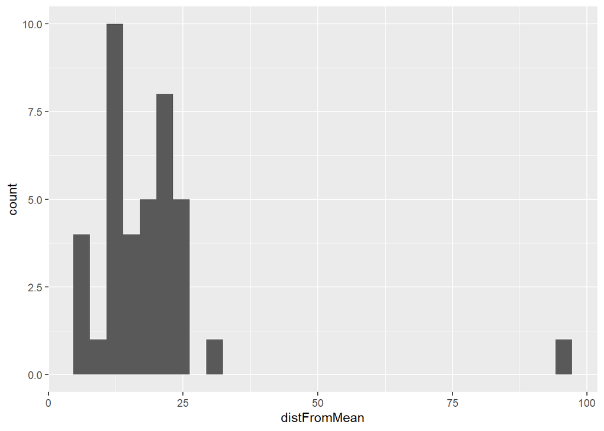

```r
g <- ggplot(usDist, aes(x = distFromMean))
g + geom_histogram()
```

Here is the histogram without the brewery from Ireland. Again, it looks nearly normally-distributed. This indicates that it is nearly representative of the population. As the above histogram, the x-axis is the distance from the mean and the y-axis consists of the corresponding frequencies of breweries’ distances from the mean.

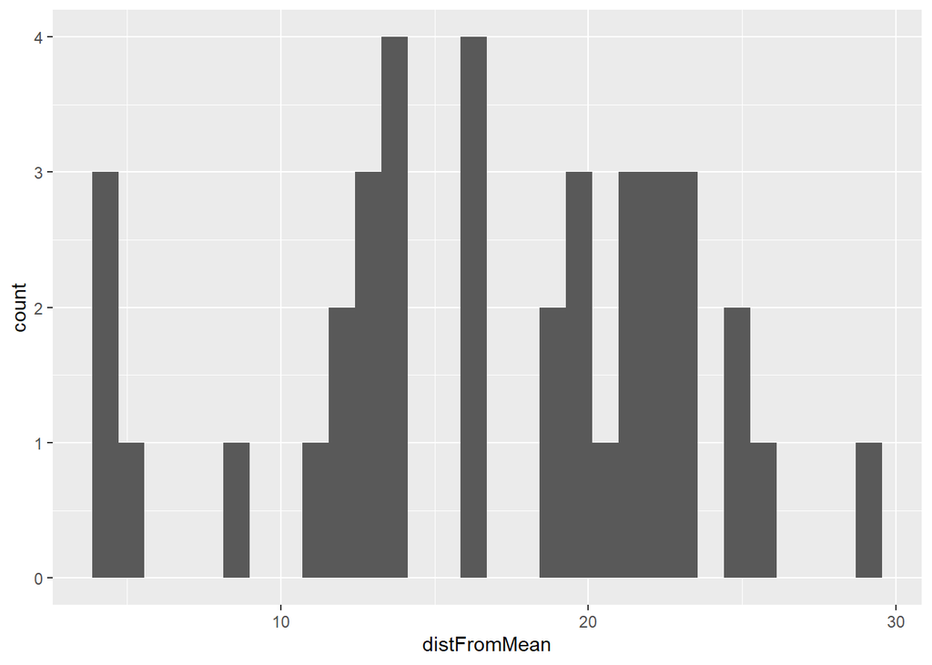

```r
g <- ggplot(na.omit(usDist), aes(x = distFromMean))
g + geom_histogram()
```

Next, let’s look at some more specific data by calling the function `get_brewery(state = "ny")` to get brewery data for the state of New York.

```r
#Get brewery data for NY
ny <- get_brewery(state = "ny")
```

We want to see if there are any patterns by type of brewery. To do this, we will investigate latitude and longitude values across brewery types. Additionally, we may want to look at the means of each type to see if they have significant variance.

```r
nyDist <- ny %>%
  select(name, brewery_type, latitude, longitude) %>%
  group_by(brewery_type) %>%
  mutate(meanLat = mean(as.numeric(latitude), na.rm = TRUE),
         meanLong = mean(as.numeric(longitude), na.rm = TRUE)) %>%
  arrange(meanLat)
nyDist
```

```
## # A tibble: 50 × 6
## # Groups:   brewery_type [6]
##    name                                  brewe…¹ latit…² longi…³ meanLat meanL…⁴
##    <chr>                                 <chr>   <chr>   <chr>     <dbl>   <dbl>
##  1 "Anheuser-Busch Inc â\u0080\u0093 Ba… large   43.165… -76.31…    41.6   -74.1
##  2 "Blue Point Brewing Co"               large   40.759… -73.02…    41.6   -74.1
##  3 "Blue Point Brewing"                  large   40.766… -73.02…    41.6   -74.1
##  4 "12 Gates Brewing Company"            brewpub <NA>    <NA>       42.5   -74.9
##  5 "16 Stone Brewpub"                    brewpub 43.242… -75.25…    42.5   -74.9
##  6 "2 Way Brewing Company"               brewpub 41.508… -73.98…    42.5   -74.9
##  7 "42 North Brewing Company"            brewpub 42.769… -78.60…    42.5   -74.9
##  8 "6 Degrees of Separation"             brewpub 41.158… -73.86…    42.5   -74.9
##  9 "Alewife Brewing Company"             brewpub 40.742… -73.95…    42.5   -74.9
## 10 "Amber Lantern Brewing Company"       brewpub 42.740… -78.13…    42.5   -74.9
## # … with 40 more rows, and abbreviated variable names ¹brewery_type, ²latitude,
## #   ³longitude, ⁴meanLong
```

Now that we have the data, let’s create a scatter plot to look for obvious patterns.

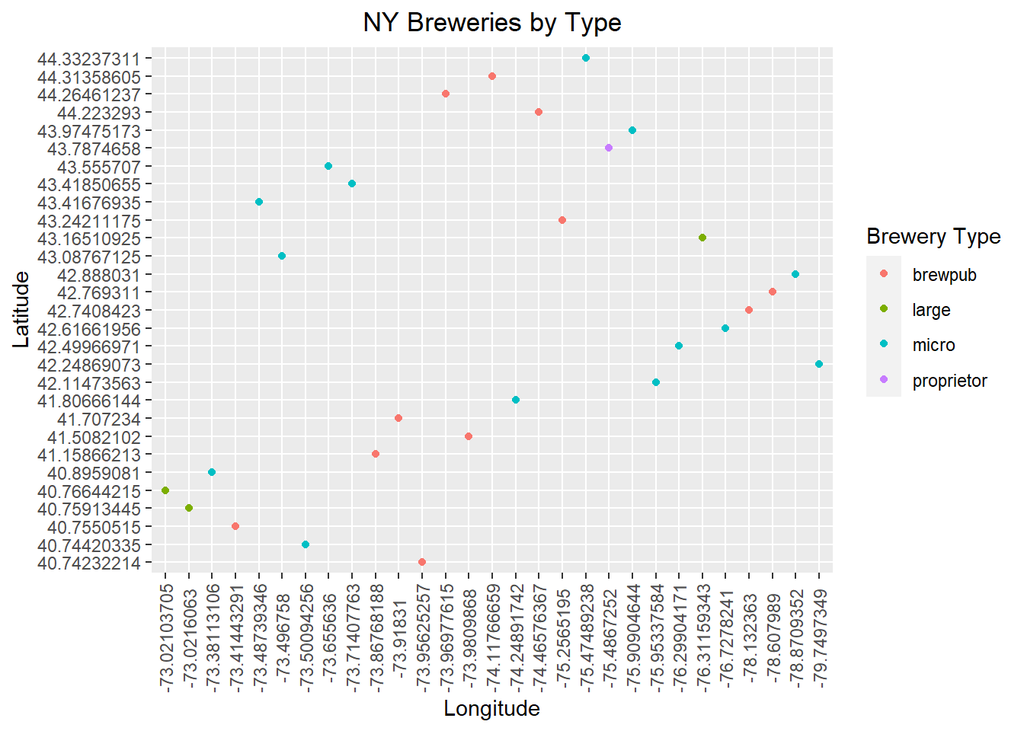

```r
g <- ggplot(na.omit(nyDist), aes(x = longitude, y = latitude))
g + geom_point(aes(color = brewery_type)) +
    labs(color = "Brewery Type", x = "Longitude", y = "Latitude") +
    theme(axis.text.x = element_text(angle = 90, vjust = 0.5)) +
    labs(title = "NY Breweries by Type", hjust = 0.5) +
    theme(plot.title = element_text(hjust = 0.5))
```

```r
nyDist %>%
  summarize(meanLat = mean(as.numeric(latitude), na.rm = TRUE),
            meanLong = mean(as.numeric(longitude), na.rm = TRUE),
            sdLat = sd(latitude, na.rm = TRUE), sdLong = sd(longitude, na.rm = TRUE))
```

```
## # A tibble: 6 × 5
##   brewery_type meanLat meanLong sdLat sdLong
##   <chr>          <dbl>    <dbl> <dbl>  <dbl>
## 1 brewpub         42.5    -74.9  1.40   1.79
## 2 contract       NaN      NaN   NA     NA
## 3 large           41.6    -74.1  1.39   1.90
## 4 micro           42.7    -75.3  1.06   2.08
## 5 planning       NaN      NaN   NA     NA
## 6 proprietor      43.8    -75.5 NA     NA
```

```r
brew <- get_brewery()

brew_reg <- brew %>%
  mutate(Region =
    if_else(brew$state %in%
    c("Connecticut", "Maine", "Massachusetts", "New Hampshire", "Rhode Island",
      "Vermont", "New Jersey", "New York", "Pennsylvania"),
    "Northeast",
    if_else(brew$state %in%
    c("Illinois", "Indiana", "Michigan", "Ohio", "Wisconsin", "Iowa", "Kansas",
      "Minnesota", "Missouri", "Nebraska", "North Dakota", "South Dakota"),
    "Midwest",
    if_else(brew$state %in%
    c("Delaware", "Florida", "Georgia", "Maryland", "North Carolina",
      "South Carolina", "Virginia", "Washington D.C.", "West Virginia",
      "Alabama", "Kentucky", "Mississippi", "Tennessee", "Arkansas",
      "Louisiana", "Oklahoma", "Texas"),
    "South",
    if_else(brew$state %in%
    c("Arizona", "Colorado", "Idaho", "Montana", "Nevada", "New Mexico", "Utah",
      "Wyoming", "Alaska", "California","Hawaii","Oregon","Washington"),
    "West",
    "Not US"))))) %>%
  select(id:state, Region, everything())

table(brew_reg$Region)
```

```
##
##   Midwest Northeast    Not US     South      West
##        11         7         1         8        23
```

```r
table(brew_reg$brewery_type)
```

```
##
##    brewpub     closed   contract      large      micro proprietor
##          9          2          1          7         30          1
```

```r
table(brew_reg$Region, brew_reg$brewery_type)
```

```
##
##             brewpub closed contract large micro proprietor
##   Midwest         1      0        0     0    10          0
##   Northeast       2      0        0     0     5          0
##   Not US          0      0        0     0     1          0
##   South           2      0        1     0     5          0
##   West            4      2        0     7     9          1
```

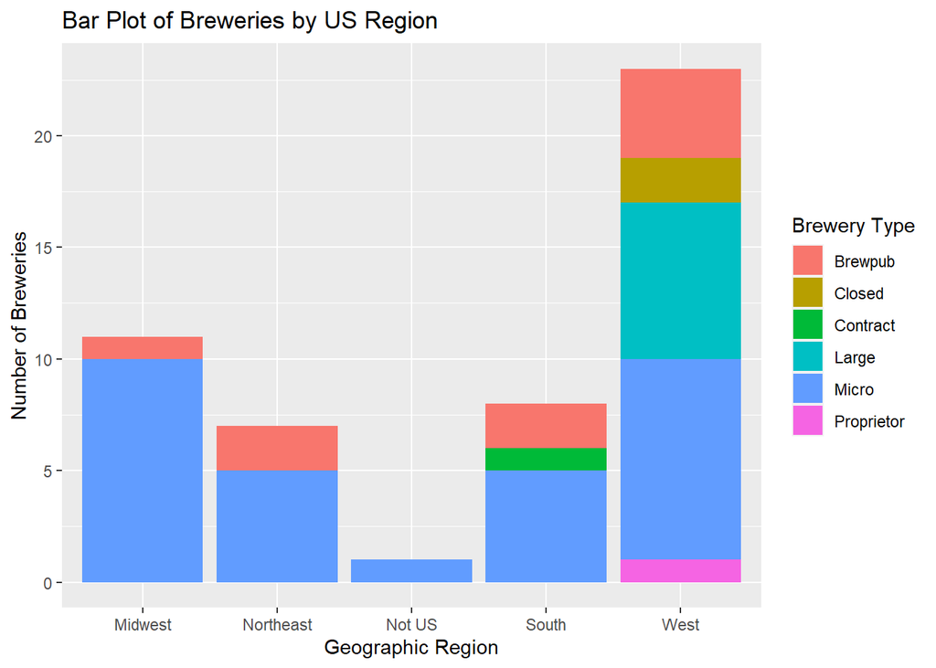

```r
g <- ggplot(brew_reg, aes(x = Region))
g + geom_bar(aes(fill = brewery_type)) +
    labs(x = "Geographic Region",
         y = "Number of Breweries",
         title = "Bar Plot of Breweries by US Region") +
    scale_fill_discrete(name = "Brewery Type",
                        labels = c("Brewpub", "Closed", "Contract", "Large",
                                   "Micro", "Proprietor")
                        )
```

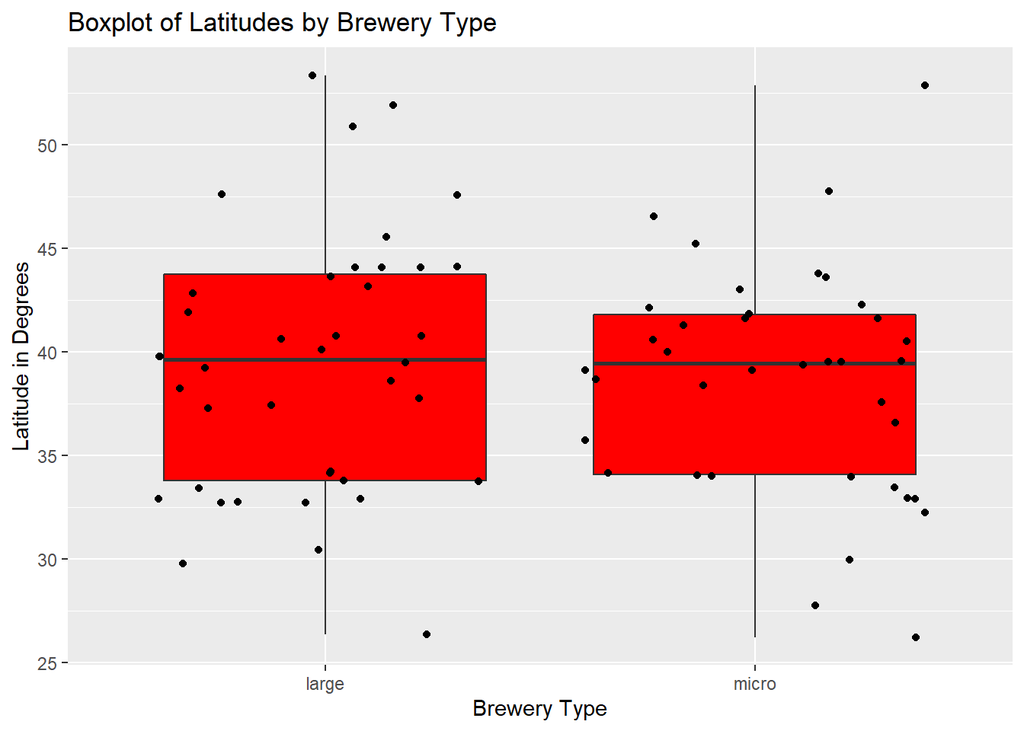

```r
micro <- get_brewery(type = "micro")
large <- get_brewery(type = "large")
combined <- bind_rows(micro, large)

g <- ggplot(combined, aes(x = brewery_type, y = as.numeric(latitude)))
g + geom_boxplot(fill = "red", na.rm = TRUE) +
    geom_jitter() +
    labs(title = "Boxplot of Latitudes by Brewery Type",
         x = "Brewery Type",
         y = "Latitude in Degrees")
```

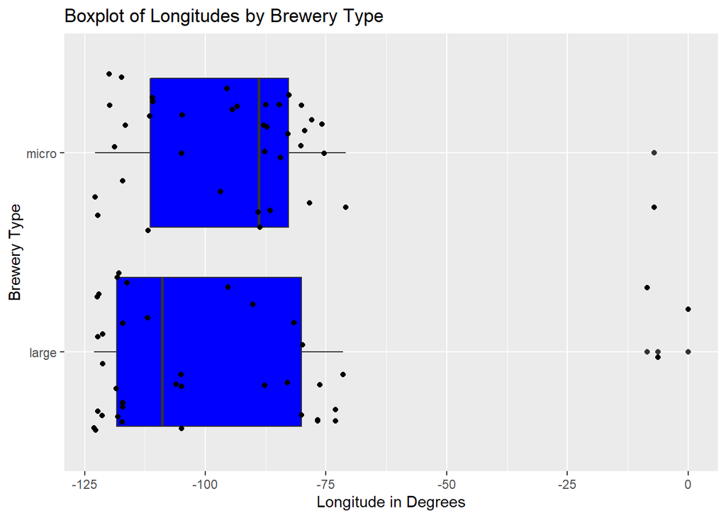

```r
g <- ggplot(combined, aes(x = brewery_type, y = as.numeric(longitude)))
g + geom_boxplot(fill = "blue", na.rm = TRUE) +
    geom_jitter() +
    coord_flip() +
    labs(title = "Boxplot of Longitudes by Brewery Type",
         x = "Brewery Type",
         y = "Longitude in Degrees")
```